# Analiza jakości snu w oparciu o styl życia

Zofia Sitek

## Wprowadzenie

Celem tego projektu jest analiza jakości snu przy określonych nawykach i prowadzonym stylu życia.  
Dane pochodzą ze zbioru danych ,,Sleep Health and Lifestyle Dataset"  
(https://www.kaggle.com/datasets/uom190346a/sleep-health-and-lifestyle-dataset), który pobrałam z platformy Kaggle 5 stycznia 2024 roku.

## O zbiorze

Zbiór zawiera 374 wiersze i 13 kolumn. Kolumny w zbiorze to:

- Person ID - Numer ID osoby
- Gender - Płeć
- Age - Wiek
- Occupation - Zawód
- Sleep Duration - Liczba godzin snu
- Quality of Sleep - Jakość snu
- Physical Activity Level - Aktywność fizyczna
- Stress Level - Poziom stresu
- BMI Category - Kategoria BMI
- Blood Pressure - Ciśnienie krwi
- Heart Rate - Tętno
- Daily Steps - Liczba kroków (dziennie)
- Sleep Disorder - Zaburzenia snu

## Potrzebne biblioteki

```python
import pandas as pd
import numpy as np
import matplotlib.pyplot as plt
import seaborn as sns
```

#### Wstępna obróbka danych

```python
data = pd.read_csv('Sleep_health_and_lifestyle_dataset.csv')
data.head()
```

|  | Person ID | Gender | Age | Occupation | Sleep Duration | Quality of Sleep | Physical Activity Level | Stress Level | BMI Category | Blood Pressure | Heart Rate | Daily Steps | Sleep Disorder |
| --- | --- | --- | --- | --- | --- | --- | --- | --- | --- | --- | --- | --- | --- |
| 0 | 1 | Male | 27 | Software Engineer | 6.1 | 6 | 42 | 6 | Overweight | 126/83 | 77 | 4200 | None |
| 1 | 2 | Male | 28 | Doctor | 6.2 | 6 | 60 | 8 | Normal | 125/80 | 75 | 10000 | None |
| 2 | 3 | Male | 28 | Doctor | 6.2 | 6 | 60 | 8 | Normal | 125/80 | 75 | 10000 | None |
| 3 | 4 | Male | 28 | Sales Representative | 5.9 | 4 | 30 | 8 | Obese | 140/90 | 85 | 3000 | Sleep Apnea |
| 4 | 5 | Male | 28 | Sales Representative | 5.9 | 4 | 30 | 8 | Obese | 140/90 | 85 | 3000 | Sleep Apnea |

```python
data.isnull().sum()
```

```
Person ID                  0
Gender                     0
Age                        0
Occupation                 0
Sleep Duration             0
Quality of Sleep           0
Physical Activity Level    0
Stress Level               0
BMI Category               0
Blood Pressure             0
Heart Rate                 0
Daily Steps                0
Sleep Disorder             0
dtype: int64
```

Jak widać, w zbiorze nie ma wartości `null`, zatem nie usuwam żadnych wierszy.

```python
data.shape
```

```
(374, 13)
```

```python
data.dtypes
```

```
Person ID                    int64
Gender                      object
Age                          int64
Occupation                  object
Sleep Duration             float64
Quality of Sleep             int64
Physical Activity Level      int64
Stress Level                 int64
BMI Category                object
Blood Pressure              object
Heart Rate                   int64
Daily Steps                  int64
Sleep Disorder              object
dtype: object
```

```python
data = data.drop(columns=['Blood Pressure', 'Daily Steps'])
```

```python
data['Quality of Sleep'].unique()
```

```
array([6, 4, 7, 5, 8, 9], dtype=int64)
```

Jak widać, jakość snu została oceniana w skali 4-9.

```python
data['Occupation'].unique()
```

```
array(['Software Engineer', 'Doctor', 'Sales Representative', 'Teacher',
       'Nurse', 'Engineer', 'Accountant', 'Scientist', 'Lawyer',
       'Salesperson', 'Manager'], dtype=object)
```

Kategoria ,,Zawód" przyjmuje 11 wartości odpowiadającym 11 różnym zawodom. Przykładowe wartości to nauczyciel, sprzedawca i pielęgniarka.

```python
data['BMI Category'].unique()
```

```
array(['Overweight', 'Normal', 'Obese'], dtype=object)
```

```python
data[data['BMI Category']=='Normal'].shape
```

```
(216, 11)
```

```python
data[data['BMI Category']=='Normal Weight'].shape
```

```
(0, 11)
```

```python
data.loc[data['BMI Category'] == 'Normal Weight', 'BMI Category'] = 'Normal'
data['BMI Category'].unique()
```

```
array(['Overweight', 'Normal', 'Obese'], dtype=object)
```

```python
data['Sleep Disorder'].unique()
```

```
array(['None', 'Sleep Apnea', 'Insomnia'], dtype=object)
```

Zaburzeniami snu uwzględnionymi w bazie jest bezsenność (Insomnia) i zespół bezdechu sennego (Sleep Apnea).

### Jaki jest rozkład?

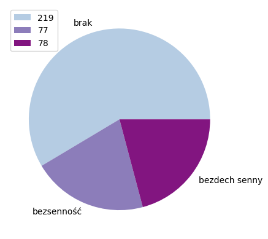

```python
sleep_dis = [0, 0, 0]
colors = sns.color_palette('BuPu')
sleep_dis[0] = data[data['Sleep Disorder']=='None'].shape[0]
sleep_dis[1] = data[data['Sleep Disorder']=='Insomnia'].shape[0]
sleep_dis[2] = data[data['Sleep Disorder']=='Sleep Apnea'].shape[0]
levels = 'brak', 'bezsenność', 'bezdech senny'
plt.pie(sleep_dis, labels=levels, colors=[colors[1], colors[3], colors[5]])
plt.legend(labels=sleep_dis, loc="upper left")
plt.show()
```

Jak można zauważyć, u przeważającej części badanych nie stwierdzono zaburzeń snu.  
Udział osób z bezsennością jest niemalże taki sam jak osób cierpiących na bezdech senny.

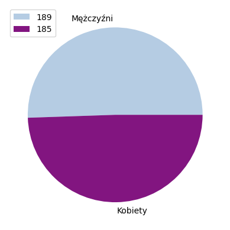

```python
# gender
m = data[data["Gender"]=="Male"].shape
f = data[data["Gender"]=="Female"].shape
plt.pie([m[0], f[0]], labels=['Mężczyźni', 'Kobiety'], colors=[colors[1], colors[5]])
plt.legend(labels=[m[0], f[0]], loc="upper left")
plt.show()
```

Wśród badanych jest 189 mężczyzn i 185 kobiet.  
Można uznać, że rozkład płci jest jak 1:1.

### Podstawowa analiza wybranych czynników

```python
sleep_duration = [
    np.mean(data['Sleep Duration'].where(data['Sleep Disorder']=='None')),
    np.mean(data['Sleep Duration'].where(data['Sleep Disorder']=='Insomnia')),
    np.mean(data['Sleep Duration'].where(data['Sleep Disorder']=='Sleep Apnea'))
]
print(sleep_duration)
```

```
[7.358447488584475, 6.58961038961039, 7.032051282051284]
```

Co ciekawe, średnia liczba godzin snu jest podobna niezależnie od tego, czy osoba cierpi na zaburzenia snu, czy nie.

### Analiza macierzy korelacji

#### Zamiana cech nominalnych na numeryczne

```python
data_num = data.copy()

gender_mapping = {'Male': 0, 'Female': 1}
data_num['Gender'] = data_num['Gender'].map(gender_mapping)

BMI_mapping = {'Normal': 0, 'Overweight': 1, 'Obese': 2}
data_num['BMI Category'] = data_num['BMI Category'].map(BMI_mapping)

data_num
```

|  | Person ID | Gender | Age | Occupation | Sleep Duration | Quality of Sleep | Physical Activity Level | Stress Level | BMI Category | Heart Rate | Sleep Disorder |
| --- | --- | --- | --- | --- | --- | --- | --- | --- | --- | --- | --- |
| 0 | 1 | 0 | 27 | Software Engineer | 6.1 | 6 | 42 | 6 | 1 | 77 | None |
| 1 | 2 | 0 | 28 | Doctor | 6.2 | 6 | 60 | 8 | 0 | 75 | None |
| 2 | 3 | 0 | 28 | Doctor | 6.2 | 6 | 60 | 8 | 0 | 75 | None |
| 3 | 4 | 0 | 28 | Sales Representative | 5.9 | 4 | 30 | 8 | 2 | 85 | Sleep Apnea |
| 4 | 5 | 0 | 28 | Sales Representative | 5.9 | 4 | 30 | 8 | 2 | 85 | Sleep Apnea |
| ... | ... | ... | ... | ... | ... | ... | ... | ... | ... | ... | ... |
| 369 | 370 | 1 | 59 | Nurse | 8.1 | 9 | 75 | 3 | 1 | 68 | Sleep Apnea |
| 370 | 371 | 1 | 59 | Nurse | 8.0 | 9 | 75 | 3 | 1 | 68 | Sleep Apnea |
| 371 | 372 | 1 | 59 | Nurse | 8.1 | 9 | 75 | 3 | 1 | 68 | Sleep Apnea |
| 372 | 373 | 1 | 59 | Nurse | 8.1 | 9 | 75 | 3 | 1 | 68 | Sleep Apnea |
| 373 | 374 | 1 | 59 | Nurse | 8.1 | 9 | 75 | 3 | 1 | 68 | Sleep Apnea |

374 rows × 11 columns

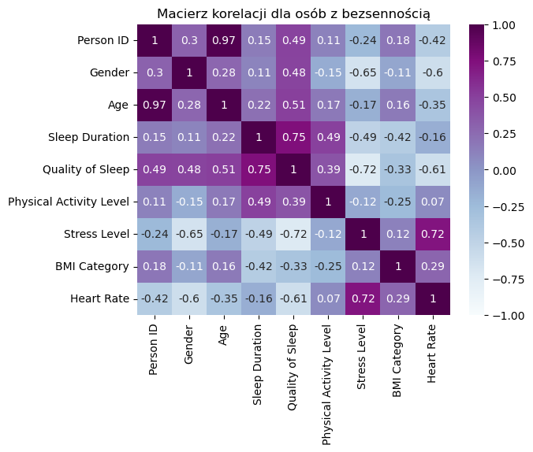

```python
data_none = data_num[data_num["Sleep Disorder"]=='None']
data_insomnia = data_num[data_num["Sleep Disorder"]=='Insomnia']
heatmap = sns.heatmap(data_insomnia.corr(numeric_only=True), vmin=-1, vmax=1, annot=True, cmap="BuPu")
plt.title('Macierz korelacji dla osób z bezsennością')
plt.show()
```

U osób cierpiących na bezsenność widać duży wpływ poziomu stresu na jakość snu. Aktywność fizyczna natomiast nie jest mocno z nią skorelowana.

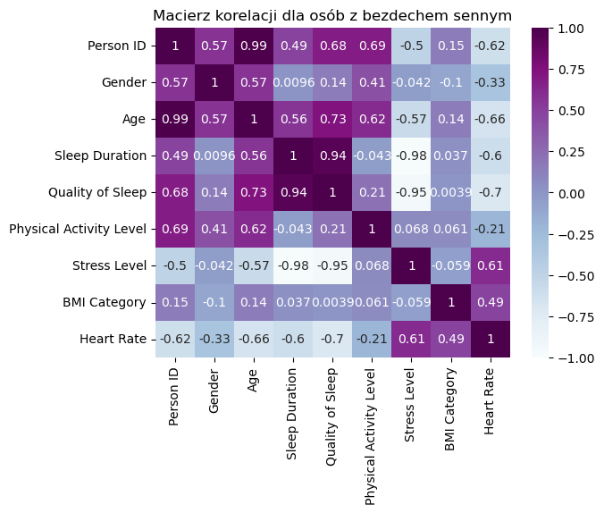

```python
data_apnea = data_num[data_num["Sleep Disorder"]=='Sleep Apnea']
heatmap = sns.heatmap(data_apnea.corr(numeric_only=True), vmin=-1, vmax=1, annot=True, cmap="BuPu")
plt.title('Macierz korelacji dla osób z bezdechem sennym')
plt.show()
```

U osób z bezdechem sennym, bardzo duży wpływ na sen ma poziom odczuwanego przez nich stresu. Zaobserwować można również duże skorelowanie z tętnem.

##### Średni poziom stresu u poszczególnych grup

```python
stress_level_none = data_none['Stress Level'].mean()
stress_level_insomnia = data_insomnia['Stress Level'].mean()
stress_level_apnea = data_apnea['Stress Level'].mean()
print(stress_level_none, stress_level_insomnia, stress_level_apnea)
```

```
5.114155251141552 5.87012987012987 5.666666666666667
```

Jak widać, najwyższy średni poziom stresu obserwuje się u osób z bezsennością.

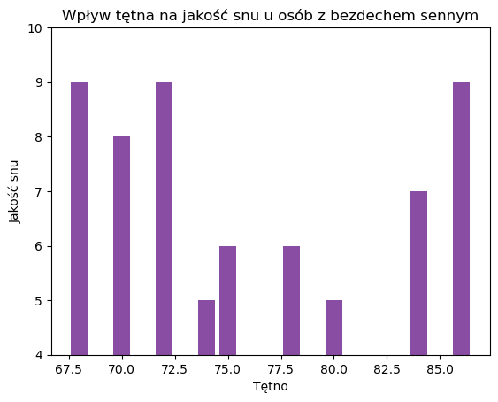

```python
plt.bar(data_apnea['Heart Rate'], data_apnea['Quality of Sleep'], color=colors[4])
plt.title('Wpływ tętna na jakość snu u osób z bezdechem sennym')
plt.xlabel('Tętno')
plt.ylim(4,10)
plt.ylabel('Jakość snu')
plt.show()
```

Jak można zauważyć, najlepszym snem śpią osoby z tętnem poniżej 72.5 i powyżej 85 uderzeń na minutę.

#### Zawód a zaburzenia snu

Sprawdzę, czy wykonywany zawód ma wpływ na występowanie zaburzeń snu.

##### Bezsenność

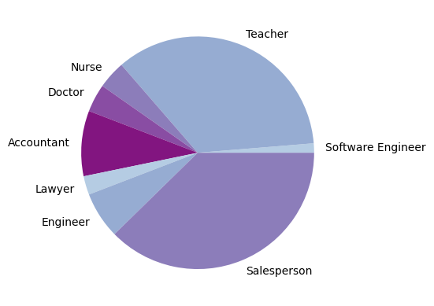

```python
occupation = data_insomnia['Occupation'].unique()
occupation_nums = [0 for i in range(len(occupation))]
colors = sns.color_palette('BuPu')

for i in range(len(occupation)):
    occupation_nums[i] = data_insomnia[data_insomnia['Occupation']==occupation[i]].shape[0]

plt.pie(occupation_nums, labels=occupation, colors=colors[1:10])
plt.show()
```

Z powyższego wykresu można wnioskować, że najbardziej narażonymi na bezsenność zawodami spośród  
obecnych w zbiorze danych są nauczyciele i sprzedawcy. Informatycy najrzadziej mają problem z bezsennością.

##### Bezdech senny

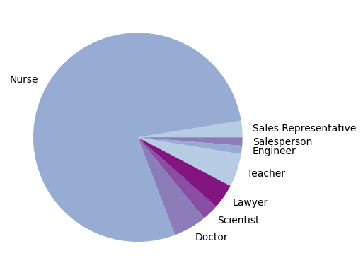

```python
occupation = data_apnea['Occupation'].unique()
occupation_nums = [0 for i in range(len(occupation))]
colors = sns.color_palette('BuPu')

for i in range(len(occupation)):
    occupation_nums[i] = data_apnea[data_apnea['Occupation']==occupation[i]].shape[0]

plt.pie(occupation_nums, labels=occupation, colors=colors[1:10])
plt.show()
```

### Wnioski

Po przeprowadzeniu analizy zbioru danych, można wysnuć następujące wnioski:

- Im większy stres, tym większa podatność na zaburzenia snu.
- Nie ma mocnego związku między wagą a jakością snu.
- Wysoka aktywność fizyczna nie oznacza, że będziemy lepiej spać.
- Zawody, które zwiększają ryzyko zaburzeń, to pielęgniarz, nauczyciel i sprzedawca.
- Informatycy rzadko cierpią na zaburzenia snu.